# Spanish translation A/B Test

Zhongyuan Zhang

1/25/2020

Goals:

Confirm that the test is actually negative. That is, it appears that the old version of the site with just one translation across Spain and LatAm performs better

Explain why that might be happening. Are the localized translations really worse?

```r
library(tidyverse)
```

```r
library(rpart)
library(rpart.plot)
library(psych)
#read data
user<-read.csv("user_table.csv",stringsAsFactors = FALSE, header= TRUE)
test<-read.csv("test_table.csv",stringsAsFactors = FALSE, header= TRUE)

#check duplication
identical(unique(user$user_id),user$user_id)# TRUE meaning no duplicated data
```

```
## [1] TRUE
```

```r
identical(unique(test$user_id),test$user_id)# TRUE meaning no duplicated data
```

```
## [1] TRUE
```

```r
# Is everyone in the user table also in the test one?
dim(user)[1]-dim(test)[1] # the answer is no
```

```
## [1] -454
```

Looks like the user table is busted and we have some users ids missing. Therefore when merging the two tables, i have to be careful to do not lose the user ids in the test table, but not in the user table.

```r
data<-left_join(test,user,by="user_id") # no data is losing in this way, for those in user but not in test,their records in test's column will be NA

str(data)
```

```
## 'data.frame':    453321 obs. of  12 variables:
##  $ user_id         : int  315281 497851 848402 290051 548435 540675 863394 527287 261625 10427 ...
##  $ date            : chr  "2015-12-03" "2015-12-04" "2015-12-04" "2015-12-03" ...
##  $ source          : chr  "Direct" "Ads" "Ads" "Ads" ...
##  $ device          : chr  "Web" "Web" "Web" "Mobile" ...
##  $ browser_language: chr  "ES" "ES" "ES" "Other" ...
##  $ ads_channel     : chr  NA "Google" "Facebook" "Facebook" ...
##  $ browser         : chr  "IE" "IE" "Chrome" "Android_App" ...
##  $ conversion      : int  1 0 0 0 0 0 0 0 0 0 ...
##  $ test            : int  0 1 0 1 1 1 0 0 1 0 ...
##  $ sex             : chr  "M" "M" "M" "F" ...
##  $ age             : int  32 21 34 22 19 22 35 22 31 33 ...
##  $ country         : chr  "Spain" "Mexico" "Spain" "Mexico" ...
```

```r
data$date<-as.Date(data$date)

summary(data)
```

```
##     user_id             date               source             device
##  Min.   :      1   Min.   :2015-11-30   Length:453321      Length:453321
##  1st Qu.: 249816   1st Qu.:2015-12-01   Class :character   Class :character
##  Median : 500019   Median :2015-12-03   Mode  :character   Mode  :character
##  Mean   : 499938   Mean   :2015-12-02
##  3rd Qu.: 749522   3rd Qu.:2015-12-04
##  Max.   :1000000   Max.   :2015-12-04
##
##  browser_language   ads_channel          browser            conversion
##  Length:453321      Length:453321      Length:453321      Min.   :0.00000
##  Class :character   Class :character   Class :character   1st Qu.:0.00000
##  Mode  :character   Mode  :character   Mode  :character   Median :0.00000
##                                                           Mean   :0.04958
##                                                           3rd Qu.:0.00000
##                                                           Max.   :1.00000
##
##       test            sex                 age          country
##  Min.   :0.0000   Length:453321      Min.   :18.00   Length:453321
##  1st Qu.:0.0000   Class :character   1st Qu.:22.00   Class :character
##  Median :0.0000   Mode  :character   Median :26.00   Mode  :character
##  Mean   :0.4764                      Mean   :27.13
##  3rd Qu.:1.0000                      3rd Qu.:31.00
##  Max.   :1.0000                      Max.   :70.00
##                                      NA's   :454
```

```r
describe(data)
```

```
##                   vars      n      mean        sd median   trimmed       mad
## user_id              1 453321 499937.51 288665.19 500019 499917.57 370443.92
## date                 2 453321       NaN        NA     NA       NaN        NA
## source*              3 453321      2.00      0.89      2      2.00      1.48
## device*              4 453321      1.55      0.50      2      1.57      0.00
## browser_language*    5 453321      1.89      0.39      2      1.95      0.00
## ads_channel*         6 181877      2.80      1.12      3      2.72      1.48
## browser*             7 453321      2.84      1.92      2      2.56      1.48
## conversion           8 453321      0.05      0.22      0      0.00      0.00
## test                 9 453321      0.48      0.50      0      0.47      0.00
## sex*                10 452867      1.58      0.49      2      1.61      0.00
## age                 11 452867     27.13      6.78     26     26.49      7.41
## country*            12 452867      9.01      4.96     10      9.08      5.93
##                   min     max  range  skew kurtosis     se
## user_id             1 1000000 999999  0.00    -1.20 428.74
## date              Inf    -Inf   -Inf    NA       NA     NA
## source*             1       3      2  0.01    -1.75   0.00
## device*             1       2      1 -0.22    -1.95   0.00
## browser_language*   1       3      2 -0.96     2.41   0.00
## ads_channel*        1       5      4  0.72    -0.16   0.00
## browser*            1       7      6  0.85    -0.41   0.00
## conversion          0       1      1  4.15    15.22   0.00
## test                0       1      1  0.09    -1.99   0.00
## sex*                1       2      1 -0.34    -1.88   0.00
## age                18      70     52  0.84     0.46   0.01
## country*            1      17     16 -0.11    -1.13   0.01
```

First question is: check test results. But even before that, let’s make sure it is true Spain converts much better than the rest of the LatAm (Try to confirm what the data scientist observe is true)

```r
#before the test
data_convertion_country<-data%>%
  group_by(country)%>%
  summarise(conversion_rate=mean(conversion[test==0]))%>%
  arrange(desc(conversion_rate))
head(data_convertion_country)
```

```
## # A tibble: 6 x 2
##   country     conversion_rate
##   <chr>                 <dbl>
## 1 Spain                0.0797
## 2 <NA>                 0.0776
## 3 El Salvador          0.0536
## 4 Nicaragua            0.0526
## 5 Costa Rica           0.0523
## 6 Colombia             0.0521
```

```r
#indeed, Spain has the top conversion rate, better than the rest of the LatAm
```

```r
# a simple t-test here should work. We have collected ~0.5MM data and test/control split is ~50/50.

data_test<-subset(data,country!="Spain") # nothing new has been added to the service in Spain, so no point in keeping those users

t.test(data_test$conversion[data_test$test==1],data_test$conversion[data_test$test==0])
```

```
##
##  Welch Two Sample t-test
##
## data:  data_test$conversion[data_test$test == 1] and data_test$conversion[data_test$test == 0]
## t = -7.3539, df = 385258, p-value = 1.929e-13
## alternative hypothesis: true difference in means is not equal to 0
## 95 percent confidence interval:
##  -0.006181421 -0.003579837
## sample estimates:
##  mean of x  mean of y
## 0.04341116 0.04829179
```

```r
library(BSDA)
z.test(x=data_test$conversion[data_test$test==1],sigma.x=0.5,y=data_test$conversion[data_test$test==0],sigma.y=0.5,)
```

```
##
##  Two-sample z-Test
##
## data:  data_test$conversion[data_test$test == 1] and data_test$conversion[data_test$test == 0]
## z = -3.082, p-value = 0.002056
## alternative hypothesis: true difference in means is not equal to 0
## 95 percent confidence interval:
##  -0.007984375 -0.001776883
## sample estimates:
##  mean of x  mean of y
## 0.04341116 0.04829179
```

```r
# in non-spain countries there's statistical significance in their mean differences between test group and control group; control group has better performance than the tested group,meaning that the change has a negative impact on the conversion-
```

Not in the test are converting at 4.8% while users in the test just at 4.3%. That’s a 10% drop, which would be dramatic if it were true. The most likely reason for weird A/B test results are:

1. We didn’t collect enough data.(The experimental time is too short)
2. Some bias has been introduced in the experiment so that test/ control people are not really random

`In data science, whenever results appear too bad or too good to be true, they are not true.`

Firstly, let’s plot day by day, to see if these weird results have been constantly happening or they just started happening all of a sudden: Treatment group and control group comparision by day.

```r
data_test_by_day<-data_test%>%
  group_by(date)%>%
  summarise(test_vs_control=mean(conversion[test==1])/
                            mean(conversion[test==0]))
```

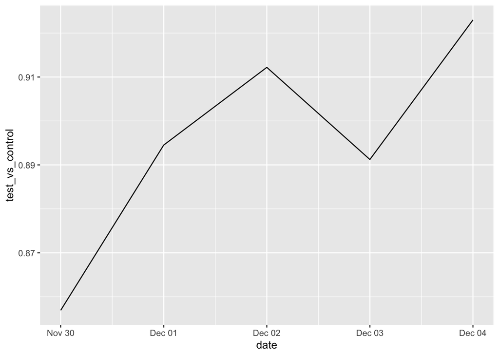

```r
qplot(x=date,y=test_vs_control,data=data_test_by_day,geom="line")
```

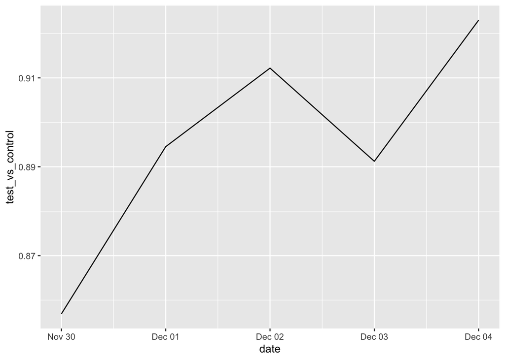

```r
ggplot(data_test_by_day,aes(x=date,test_vs_control))+
  geom_line()
```

From the plot we could tell that 1. All of the test_vs_control are smaller than 1, meaning that Test has been constantly worse than control. There’s relatively little variance across the days. That probably means that we do have enough data, but there was some bias in the experiment set up.

2. But there is this rising trend that could possibly exceed 1. And on a side note, the testing just ran for 5 days. Normally, it should always run at least 1 full week to capture weekly pattern, **2** weeks would be predicably better.

`Likely, there is for some reason some segments of users more likely to end up in test or in control, this segment had a significantly above/ below conversion rate and this affected the overall results.`

In an ideal world, the distribution of people in test and control for each segment should be the same.  
There are many ways to check this.

One way is to build a **decision tree** where the variables are the user dimensions and the outcome variable is whether the user is in test or control. If the tree splits, it means that for given values of that variable you are more likely to end up in test or control. But this should be impossible! Therefore, if `the randomization worked`, the tree **should not** split at all(or at least not be able to separate the two classes well)

```r
tree<-rpart(test~.,data_test[,-8],control=rpart.control(minbucket = nrow(data_test)/100,maxdepth = 2))
# we remove conversion. Doesn't matter now since we are considering pre-experiment grouping
# we only look for segments representing at least 1% of the populations.

tree # here we are not interested in predictive power, we are mainly using the tree as a descriptive stat tool
```

```
## n= 401085
##
## node), split, n, deviance, yval
##       * denotes terminal node
##
## 1) root 401085 99692.820 0.5379757
##   2) country=Bolivia,Chile,Colombia,Costa Rica,Ecuador,El Salvador,Guatemala,Honduras,Mexico,Nicaragua,Panama,Paraguay,Peru,Venezuela 350218 87553.970 0.4987693 *
##   3) country=Argentina,Uruguay 50867  7894.097 0.8079108 *
```

```r
summary(tree)
```

```
## Call:
## rpart(formula = test ~ ., data = data_test[, -8], control = rpart.control(minbucket = nrow(data_test)/100,
##     maxdepth = 2))
##   n= 401085
##
##           CP nsplit rel error    xerror         xstd
## 1 0.04257835      0 1.0000000 1.0000035 0.0002405540
## 2 0.01000000      1 0.9574216 0.9574277 0.0005843567
##
## Variable importance
## country
##     100
##
## Node number 1: 401085 observations,    complexity param=0.04257835
##   mean=0.5379757, MSE=0.2485578
##   left son=2 (350218 obs) right son=3 (50867 obs)
##   Primary splits:
##       country splits as  RLLLLLLLLLLLLLRL, improve=4.257835e-02, (0 missing)
##       browser splits as  RRRLRLL, improve=2.622407e-05, (0 missing)
##       user_id < 947125.5 to the right, improve=1.462860e-05, (0 missing)
##       age     < 26.5     to the right, improve=6.093216e-06, (0 missing)
##       source  splits as  LLR, improve=4.293062e-06, (0 missing)
##
## Node number 2: 350218 observations
##   mean=0.4987693, MSE=0.2499985
##
## Node number 3: 50867 observations
##   mean=0.8079108, MSE=0.1551909
```

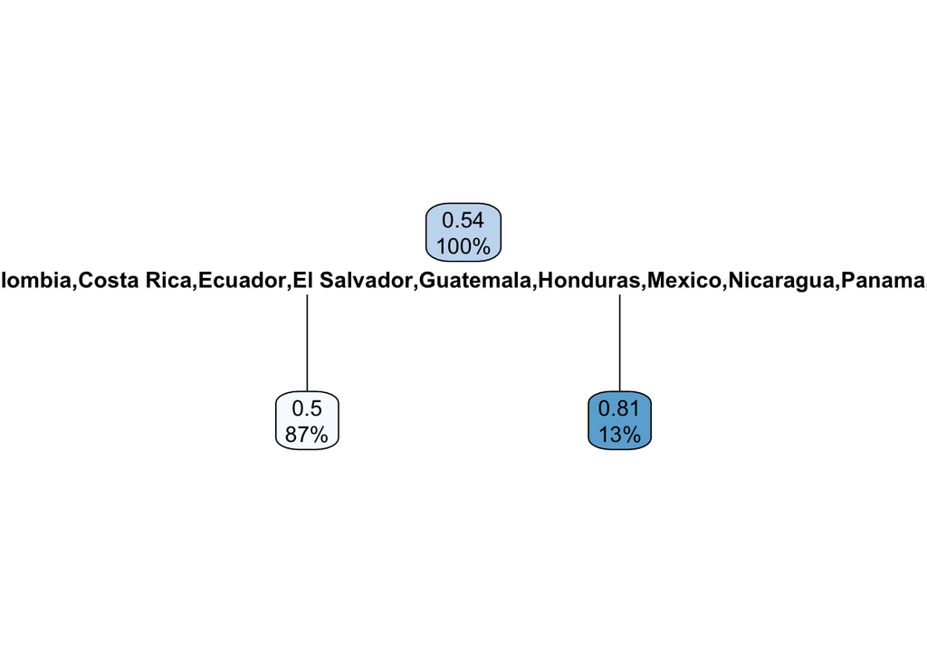

```r
rpart.plot(tree)
```

The summary looks very interesting. The randomizaton is perfect for the countries on one side of the split(country=Bolivia,Chile,Colombia,Costa Rica,Ecuador,El Salvador,Guatemala,Honduras,Mexico,Nicaragua,Panama,Paraguay,Peru,Venezuela) Indeed, in that leaf the test/control ratio is 0.498!

However, Argentina and Uruguary together have 80% test and 20% control! And we could conlude that the unexpected outcome was caused by the bias in country distribution.

So let’s check the test results after controlling for country. That is, we check for each country how the test is doing:

```r
data_test_country<-data_test%>%
  group_by(country)%>%
  summarize(p_value=t.test(conversion[test==1],conversion[test==0])$p.value,
            conversion_test=t.test(conversion[test==1],conversion[test==0])$estimate[1],
            conversion_control=t.test(conversion[test==1],conversion[test==0])$estimate[2]
            )%>%
  arrange(p_value)
data_test_country
```

```
## # A tibble: 16 x 4
##    country     p_value conversion_test conversion_control
##    <chr>         <dbl>           <dbl>              <dbl>
##  1 Mexico        0.166          0.0512             0.0495
##  2 El Salvador   0.248          0.0479             0.0536
##  3 Chile         0.303          0.0513             0.0481
##  4 Argentina     0.335          0.0137             0.0151
##  5 Colombia      0.424          0.0506             0.0521
##  6 Honduras      0.471          0.0475             0.0509
##  7 Guatemala     0.572          0.0486             0.0506
##  8 Venezuela     0.574          0.0490             0.0503
##  9 Costa Rica    0.688          0.0547             0.0523
## 10 Panama        0.705          0.0494             0.0468
## 11 Bolivia       0.719          0.0479             0.0494
## 12 Peru          0.772          0.0506             0.0499
## 13 Nicaragua     0.780          0.0542             0.0526
## 14 Uruguay       0.880          0.0129             0.0120
## 15 Paraguay      0.884          0.0492             0.0485
## 16 Ecuador       0.962          0.0490             0.0492
```

After we control for country, the test clearly appears non-significant. Not a great success given that the goal was to improve conversion rate, **but at least we know that a localized translation didn’t make things worse!**